# M3T3 - Evaluate Techniques for Wifi Locationing

Wi-Fi positioning system (WPS), is used when GPS can’t receive the signal. To improve the user experience, it exist the Wi-Fi Fingerprinting. That system consist of estimating the position of a user using a smartphone that sends a signal (the fingerprint or instance) that is recived by a Wireless Access Points (WAPs). Two files “trainingData.csv” and “validationData.csv” will be used to solve this problem.

# 1 Enviroment Setup

## 1.1 Load Packages

## 1.2 Load Data

```r
#-Training Data
train <- read.csv("~/R/XTOL/Module3/Task3/trainingData.csv")
valid <- read.csv("~/R/XTOL/Module3/Task3/validationData.csv")
dim(train)
```

```
[1] 19937   529
```

```r
dim(valid)
```

```
[1] 1111  529
```

```r
# Attribute Definitions
wifi_defTable <- read.csv("~/R/XTOL/Module3/Task3/definition_table.csv")

#-Generate table of variable definitions
kable(wifi_defTable, caption = 'Attribute Definitions') %>%   kable_styling(bootstrap_options = c('striped', 'hover', 'responsive', 'bordered'),
                full_width = F,
                font_size = 14)
```

Attribute Definitions

| Attribute | Definition |
| --- | --- |
| (WAP001) | Intensity value for WAP001. Negative integer values from -104 to 0 and +100. Positive value 100 used if WAP001 was not detected. |
| ?.. |  |
| (WAP520) | Intensity value for WAP520. Negative integer values from -104 to 0 and +100. Positive Vvalue 100 used if WAP520 was not detected. |
| (Longitude) | Longitude. Negative real values from -7695.9387549299299000 to -7299.786516730871000 |
| (Latitude) | Latitude. Positive real values from 4864745.7450159714 to 4865017.3646842018. |
| (Floor) | Altitude in floors inside the building. Integer values from 0 to 4. |
| (BuildingID) | ID to identify the building. Measures were taken in three different buildings. Categorical integer values from 0 to 2. |
| (SpaceID) | Internal ID number to identify the Space (office, corridor, classroom) where the capture was taken. Categorical integer values. |
| (RelativePosition) | Relative position with respect to the Space (1 - Inside, 2 - Outside in Front of the door). Categorical integer values. |
| (UserID) | User identifier (see below). Categorical integer values. |
| (PhoneID) | Android device identifier (see below). Categorical integer values. |
| (Timestamp) | UNIX Time when the capture was taken. Integer value. |

## 1.3 Data Exploration

```r
summary(train[,510:529])
```

```
     WAP510           WAP511            WAP512           WAP513           WAP514           WAP515           WAP516
 Min.   :-97.00   Min.   :-103.00   Min.   :-97.00   Min.   :-92.00   Min.   :-90.00   Min.   :-97.00   Min.   :-101.00
 1st Qu.:100.00   1st Qu.: 100.00   1st Qu.:100.00   1st Qu.:100.00   1st Qu.:100.00   1st Qu.:100.00   1st Qu.: 100.00
 Median :100.00   Median : 100.00   Median :100.00   Median :100.00   Median :100.00   Median :100.00   Median : 100.00
 Mean   : 99.99   Mean   :  84.97   Mean   : 99.87   Mean   : 98.88   Mean   : 98.83   Mean   : 99.44   Mean   :  73.71
 3rd Qu.:100.00   3rd Qu.: 100.00   3rd Qu.:100.00   3rd Qu.:100.00   3rd Qu.:100.00   3rd Qu.:100.00   3rd Qu.: 100.00
 Max.   :100.00   Max.   : 100.00   Max.   :100.00   Max.   :100.00   Max.   :100.00   Max.   :100.00   Max.   : 100.00
     WAP517            WAP518           WAP519           WAP520      LONGITUDE        LATITUDE           FLOOR
 Min.   :-101.00   Min.   :-97.00   Min.   :-97.00   Min.   :100   Min.   :-7691   Min.   :4864746   Min.   :0.000
 1st Qu.: 100.00   1st Qu.:100.00   1st Qu.:100.00   1st Qu.:100   1st Qu.:-7595   1st Qu.:4864821   1st Qu.:1.000
 Median : 100.00   Median :100.00   Median :100.00   Median :100   Median :-7423   Median :4864852   Median :2.000
 Mean   :  59.89   Mean   : 99.79   Mean   : 99.97   Mean   :100   Mean   :-7464   Mean   :4864871   Mean   :1.675
 3rd Qu.: 100.00   3rd Qu.:100.00   3rd Qu.:100.00   3rd Qu.:100   3rd Qu.:-7359   3rd Qu.:4864930   3rd Qu.:3.000
 Max.   : 100.00   Max.   :100.00   Max.   :100.00   Max.   :100   Max.   :-7301   Max.   :4865017   Max.   :4.000
   BUILDINGID       SPACEID      RELATIVEPOSITION     USERID          PHONEID        TIMESTAMP
 Min.   :0.000   Min.   :  1.0   Min.   :1.000    Min.   : 1.000   Min.   : 1.00   Min.   :1.370e+09
 1st Qu.:0.000   1st Qu.:110.0   1st Qu.:2.000    1st Qu.: 5.000   1st Qu.: 8.00   1st Qu.:1.371e+09
 Median :1.000   Median :129.0   Median :2.000    Median :11.000   Median :13.00   Median :1.372e+09
 Mean   :1.213   Mean   :148.4   Mean   :1.833    Mean   : 9.068   Mean   :13.02   Mean   :1.371e+09
 3rd Qu.:2.000   3rd Qu.:207.0   3rd Qu.:2.000    3rd Qu.:13.000   3rd Qu.:14.00   3rd Qu.:1.372e+09
 Max.   :2.000   Max.   :254.0   Max.   :2.000    Max.   :18.000   Max.   :24.00   Max.   :1.372e+09
```

```r
summary(valid[,510:529])
```

```
     WAP510        WAP511        WAP512        WAP513        WAP514        WAP515        WAP516        WAP517        WAP518
 Min.   :100   Min.   :100   Min.   :100   Min.   :100   Min.   :100   Min.   :100   Min.   :100   Min.   :100   Min.   :100
 1st Qu.:100   1st Qu.:100   1st Qu.:100   1st Qu.:100   1st Qu.:100   1st Qu.:100   1st Qu.:100   1st Qu.:100   1st Qu.:100
 Median :100   Median :100   Median :100   Median :100   Median :100   Median :100   Median :100   Median :100   Median :100
 Mean   :100   Mean   :100   Mean   :100   Mean   :100   Mean   :100   Mean   :100   Mean   :100   Mean   :100   Mean   :100
 3rd Qu.:100   3rd Qu.:100   3rd Qu.:100   3rd Qu.:100   3rd Qu.:100   3rd Qu.:100   3rd Qu.:100   3rd Qu.:100   3rd Qu.:100
 Max.   :100   Max.   :100   Max.   :100   Max.   :100   Max.   :100   Max.   :100   Max.   :100   Max.   :100   Max.   :100
     WAP519        WAP520         LONGITUDE        LATITUDE           FLOOR         BUILDINGID        SPACEID  RELATIVEPOSITION
 Min.   :100   Min.   :-74.00   Min.   :-7696   Min.   :4864748   Min.   :0.000   Min.   :0.0000   Min.   :0   Min.   :0
 1st Qu.:100   1st Qu.:100.00   1st Qu.:-7637   1st Qu.:4864843   1st Qu.:1.000   1st Qu.:0.0000   1st Qu.:0   1st Qu.:0
 Median :100   Median :100.00   Median :-7560   Median :4864915   Median :1.000   Median :1.0000   Median :0   Median :0
 Mean   :100   Mean   : 99.84   Mean   :-7529   Mean   :4864902   Mean   :1.572   Mean   :0.7588   Mean   :0   Mean   :0
 3rd Qu.:100   3rd Qu.:100.00   3rd Qu.:-7421   3rd Qu.:4864967   3rd Qu.:2.000   3rd Qu.:1.0000   3rd Qu.:0   3rd Qu.:0
 Max.   :100   Max.   :100.00   Max.   :-7300   Max.   :4865017   Max.   :4.000   Max.   :2.0000   Max.   :0   Max.   :0
     USERID     PHONEID        TIMESTAMP
 Min.   :0   Min.   : 0.00   Min.   :1.380e+09
 1st Qu.:0   1st Qu.: 9.00   1st Qu.:1.380e+09
 Median :0   Median :13.00   Median :1.381e+09
 Mean   :0   Mean   :11.92   Mean   :1.381e+09
 3rd Qu.:0   3rd Qu.:15.00   3rd Qu.:1.381e+09
 Max.   :0   Max.   :21.00   Max.   :1.381e+09
```

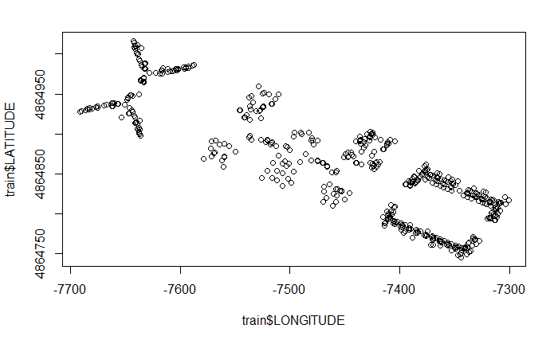

```r
# Plot location with both data sets
plot(train$LONGITUDE, train$LATITUDE)
```

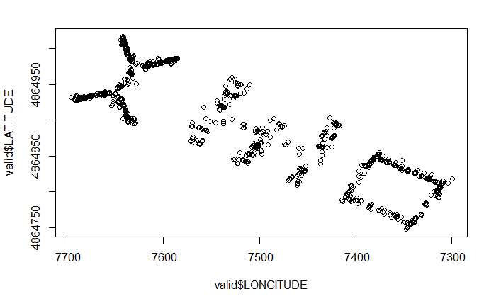

```r
plot(valid$LONGITUDE, valid$LATITUDE)
```

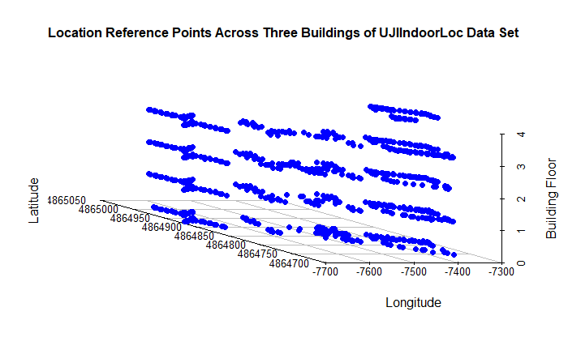

```r
#3D image of reference point locations in data set
scatterplot3d(train$LONGITUDE, train$LATITUDE, train$FLOOR,
              type='p',
              highlight.3d = FALSE,
              color='blue',
              angle=155,
              pch=16,
              box=FALSE,
              main = "Location Reference Points Across Three Buildings of UJIIndoorLoc Data Set",
              cex.lab = 1,
              cex.main=1,
              cex.sub=1,
              col.sub='blue',
              xlab='Longitude', ylab='Latitude',zlab = 'Building Floor')
```

# 2 Pre-processing

```r
#Merge both data. Divide full data
set.seed(100)
data <- rbind(train, valid)
sample <- sample.split(data, SplitRatio = .70)
training <- subset(data, sample ==TRUE)
validation <- subset(data, sample == FALSE)
```

## 2.1 Separate data by building

```r
#Separate data by building in train & valid
build.0 <- filter(training, BUILDINGID == 0)
build.1 <- filter(training, BUILDINGID == 1)
build.2 <- filter(training, BUILDINGID == 2)

build.0.v <- filter(validation, BUILDINGID == 0)
build.1.v <- filter(validation, BUILDINGID == 1)
build.2.v <- filter(validation, BUILDINGID == 2)

#Create a data frame for each feature
#TRAIN
#Build 0
build.0.lat <- data.frame(build.0$LATITUDE, build.0[,1:520])
build.0.long <- data.frame(build.0$LONGITUDE, build.0[,1:520])
build.0.floor <- data.frame(build.0$FLOOR, build.0[,1:520])

#Build 1
build.1.lat <- data.frame(build.1$LATITUDE, build.1[,1:520])
build.1.long <- data.frame(build.1$LONGITUDE, build.1[,1:520])
build.1.floor <- data.frame(build.1$FLOOR, build.1[,1:520])

#Build 2
build.2.lat <- data.frame(build.2$LATITUDE, build.2[,1:520])
build.2.long <- data.frame(build.2$LONGITUDE, build.2[,1:520])
build.2.floor <- data.frame(build.2$FLOOR, build.2[,1:520])

#VALID
#Build 0
build.0.lat.v <- data.frame(build.0.v$LATITUDE, build.0.v[,1:520])
build.0.long.v <- data.frame(build.0.v$LONGITUDE, build.0.v[,1:520])
build.0.floor.v <- data.frame(build.0.v$FLOOR, build.0.v[,1:520])

#Build 1
build.1.lat.v <- data.frame(build.1.v$LATITUDE, build.1.v[,1:520])
build.1.long.v <- data.frame(build.1.v$LONGITUDE, build.1.v[,1:520])
build.1.floor.v <- data.frame(build.1.v$FLOOR, build.1.v[,1:520])

#Build 2
build.2.lat.v <- data.frame(build.2.v$LATITUDE, build.2.v[,1:520])
build.2.long.v <- data.frame(build.2.v$LONGITUDE, build.2.v[,1:520])
build.2.floor.v <- data.frame(build.2.v$FLOOR, build.2.v[,1:520])
```

## 2.2 Data Sampling

```r
#Sample the data taking X random values
#TRAIN
#Build 0
sample.build.0.lat <- build.0.lat[sample(1:nrow(build.0.lat), 4000, replace = FALSE),]
sample.build.0.long <- build.0.long[sample(1:nrow(build.0.long), 4000, replace = FALSE),]
sample.build.0.floor <- build.0.floor[sample(1:nrow(build.0.floor), 4000, replace = FALSE),]
#Build 1
sample.build.1.lat <- build.1.lat[sample(1:nrow(build.1.lat), 3000, replace = FALSE),]
sample.build.1.long <- build.1.long[sample(1:nrow(build.1.long), 3000, replace = FALSE),]
sample.build.1.floor <- build.1.floor[sample(1:nrow(build.1.floor), 3000, replace = FALSE),]
#Build 2
sample.build.2.lat <- build.2.lat[sample(1:nrow(build.2.lat), 6000, replace = FALSE),]
sample.build.2.long <- build.2.long[sample(1:nrow(build.2.long), 6000, replace = FALSE),]
sample.build.2.floor <- build.2.floor[sample(1:nrow(build.2.floor), 6000, replace = FALSE),]

#Convert FLOOR fetaure in factor
sample.build.0.floor$build.0.FLOOR <- as.factor(sample.build.0.floor$build.0.FLOOR)
sample.build.1.floor$build.1.FLOOR <- as.factor(sample.build.1.floor$build.1.FLOOR)
sample.build.2.floor$build.2.FLOOR <- as.factor(sample.build.2.floor$build.2.FLOOR)
```

# 3 Fiting Models

## 3.1 KNN

### 3.1.1 Building 0

```r
### Building 0 ###

# Train Control
trctrlKNN <- trainControl(method = "cv", number = 5, verboseIter = TRUE)
preProcessKNN <- c("zv", "medianImpute")

### Model Training ###
# Latitud #
knn.lat.0 <- train(build.0.LATITUDE ~ ., sample.build.0.lat, method = "knn", trControl = trctrlKNN, preProcess = preProcessKNN)
# Longitud #
knn.long.0 <- train(build.0.LONGITUDE ~ ., sample.build.0.long, method = "knn", trControl = trctrlKNN, preProcess = preProcessKNN)
# Floor #
knn.floor.0 <- train(build.0.FLOOR ~ ., sample.build.0.floor, method = "knn", trControl = trctrlKNN , preProcess = preProcessKNN)
### Prediction ###
# Latitud #
pred.knn.lat.0 <- predict(knn.lat.0, build.0.lat.v)

# Longitud #
pred.knn.long.0 <- predict(knn.long.0, build.0.long.v)

# Floor #
pred.knn.floor.0 <- predict(knn.floor.0, build.0.floor.v)

# Post Resample #
# Latitud #
PRKNNb0lat0 <- postResample(pred.knn.lat.0, build.0.lat.v$build.0.v.LATITUDE)
PRKNNb0lat0
```

```
     RMSE  Rsquared       MAE
4.6174511 0.9811956 2.6828663
```

```r
# Longitud #
PRKNNb0lon0 <- postResample(pred.knn.long.0, build.0.long.v$build.0.v.LONGITUDE)
PRKNNb0lon0
```

```
    RMSE Rsquared      MAE
5.959225 0.944324 3.504728
```

```r
# Accuracy #
conf.matrix.knn.floor.0 <- table(pred.knn.floor.0, build.0.floor.v$build.0.v.FLOOR)
accuracy.knn.floor.0 <- (sum(diag(conf.matrix.knn.floor.0))) / sum(conf.matrix.knn.floor.0)
accuracy.knn.floor.0 <- accuracy.knn.floor.0 * 100
accuracy.knn.floor.0
```

```
[1] 93.88344
```

### 3.1.2 Building 1

```r
### Building 1 ###
### Model Training ###
# Latitud #
knn.lat.1 <- train(build.1.LATITUDE ~ ., sample.build.1.lat, method = "knn", trControl = trctrlKNN, preProcess = preProcessKNN)
# Longitud #
knn.long.1 <- train(build.1.LONGITUDE ~ ., sample.build.1.long, method = "knn", trControl = trctrlKNN, preProcess = preProcessKNN)
# Floor #
knn.floor.1 <- train(build.1.FLOOR ~ ., sample.build.1.floor, method = "knn", trControl = trctrlKNN , preProcess = preProcessKNN)
### Prediction ###
# Latitud #
pred.knn.lat.1 <- predict(knn.lat.1, build.1.lat.v)

# Longitud #
pred.knn.long.1 <- predict(knn.long.1, build.1.long.v)

# Floor #
pred.knn.floor.1 <- predict(knn.floor.1, build.1.floor.v)

# Post Resample #
# Latitud #
PRKNNb0lat1 <- postResample(pred.knn.lat.1, build.1.lat.v$build.1.v.LATITUDE)
PRKNNb0lat1
```

```
    RMSE Rsquared      MAE
7.726009 0.955918 4.617759
```

```r
# Longitud #
PRKNNb0lon1 <- postResample(pred.knn.long.1, build.1.long.v$build.1.v.LONGITUDE)
PRKNNb0lon1
```

```
    RMSE Rsquared      MAE
8.134398 0.972738 4.696060
```

```r
# Accuracy #
conf.matrix.knn.floor.1 <- table(pred.knn.floor.1, build.1.floor.v$build.1.v.FLOOR)
accuracy.knn.floor.1 <- (sum(diag(conf.matrix.knn.floor.1))) / sum(conf.matrix.knn.floor.1)
accuracy.knn.floor.1 <- accuracy.knn.floor.1 * 100
accuracy.knn.floor.1
```

```
[1] 94.87334
```

### 3.1.3 Building 2

```r
### Building 2 ###
### Model Training ###
# Latitud #
knn.lat.2 <- train(build.2.LATITUDE ~ ., sample.build.2.lat, method = "knn", trControl = trctrlKNN, preProcess = preProcessKNN)
# Longitud #
knn.long.2 <- train(build.2.LONGITUDE ~ ., sample.build.2.long, method = "knn", trControl = trctrlKNN, preProcess = preProcessKNN)
# Floor #
knn.floor.2 <- train(build.2.FLOOR ~ ., sample.build.2.floor, method = "knn", trControl = trctrlKNN , preProcess = preProcessKNN)
### Prediction ###
# Latitud #
pred.knn.lat.2 <- predict(knn.lat.2, build.2.lat.v)

# Longitud #
pred.knn.long.2 <- predict(knn.long.2, build.2.long.v)

# Floor #
pred.knn.floor.2 <- predict(knn.floor.2, build.2.floor.v)

### Post Resample ###
# Latitud #
PRKNNb0lat2 <- postResample(pred.knn.lat.2, build.2.lat.v$build.2.v.LATITUDE)
PRKNNb0lat2
```

```
    RMSE Rsquared      MAE
6.164374 0.951474 3.199131
```

```r
# Longitud #
PRKNNb0lon2 <- postResample(pred.knn.long.2, build.2.long.v$build.2.v.LONGITUDE)
PRKNNb0lon2
```

```
     RMSE  Rsquared       MAE
8.7742755 0.9154705 4.4217772
```

```r
# Accuracy #
conf.matrix.knn.floor.2 <- table(pred.knn.floor.2, build.2.floor.v$build.2.v.FLOOR)
accuracy.knn.floor.2 <- (sum(diag(conf.matrix.knn.floor.2))) / sum(conf.matrix.knn.floor.2)
accuracy.knn.floor.2 <- accuracy.knn.floor.2 * 100
accuracy.knn.floor.2
```

```
[1] 97.1711
```

### 3.1.4 Save KNN Models

```r
# Building 0
saveKNN.lat.0 <- saveRDS(knn.lat.0, 'modelknn.lat.0.rds')
saveKNN.long.0 <- saveRDS(knn.long.0, 'modelknn.long.0.rds')
saveKNN.floor.0 <- saveRDS(knn.floor.0, 'modelknn.floor.0.rds')

# Building 1
saveKNN.lat.1 <- saveRDS(knn.lat.1, 'modelGknn.lat.1.rds')
saveKNN.long.1 <- saveRDS(knn.long.1, 'modelknn.long.1.rds')
saveKNN.floor.1 <- saveRDS(knn.floor.1, 'modelknn.floor.1.rds')

# Building 2
saveKNN.lat.2 <- saveRDS(knn.lat.2, 'modelknn.lat.2.rds')
saveKNN.long.2 <- saveRDS(knn.long.2, 'modelknn.long.2.rds')
saveKNN.floor.2 <- saveRDS(knn.floor.2, 'modelknn.floor.2.rds')
```

## 3.2 Random Forest

### 3.2.1 Building 0

```r
# Train Control
trctrlRF <- trainControl(method = "cv", number = 5, verboseIter = TRUE)
preProcessRF <- c("zv", "medianImpute")
tunegridRF <- expand.grid(mtry=c(32))

### Building 0 ###
### Model Training ###
# Latitud #
rfor.lat.0 <- train(build.0.LATITUDE ~ ., sample.build.0.lat, method = "rf", tuneGrid= tunegridRF, trControl = trctrlRF, preProcess = preProcessRF)
# Longitud #
rfor.long.0 <- train(build.0.LONGITUDE ~ ., sample.build.0.long, method = "rf", tuneGrid= tunegridRF, trControl = trctrlRF, preProcess = preProcessRF)
# Floor #
rfor.floor.0 <- train(build.0.FLOOR ~ ., sample.build.0.floor, method = "rf", tuneGrid= tunegridRF, trControl = trctrlRF, preProcess = preProcessRF)
### Prediction ###
# Latitud #
pred.rfor.lat.0 <- predict(rfor.lat.0, build.0.lat.v)

# Longitud #
pred.rfor.long.0 <- predict(rfor.long.0, build.0.long.v)

# Floor #
pred.rfor.floor.0 <- predict(rfor.floor.0, build.0.floor.v)

### Post Resample ###
# Latitud #
PRRFb0lat0 <- postResample(pred.rfor.lat.0, build.0.lat.v$build.0.v.LATITUDE)
PRRFb0lat0
```

```
     RMSE  Rsquared       MAE
3.3082446 0.9902993 2.1206168
```

```r
# Longitud #
PRRFb0lon0 <- postResample(pred.rfor.long.0, build.0.long.v$build.0.v.LONGITUDE)
PRRFb0lon0
```

```
     RMSE  Rsquared       MAE
4.1715624 0.9736372 2.7170267
```

```r
### Accuracy ###
#Floor
conf.matrix.rfor.floor.0 <- table(pred.rfor.floor.0, build.0.floor.v$build.0.v.FLOOR)
accuracy.rfor.floor.0 <- (sum(diag(conf.matrix.rfor.floor.0))) / sum(conf.matrix.rfor.floor.0)
accuracy.rfor.floor.0 <- accuracy.rfor.floor.0 * 100
accuracy.rfor.floor.0
```

```
[1] 99.24986
```

### 3.2.2 Building 1

```r
### Building 1 ###
### Model Training ###
# Latitud #
rfor.lat.1 <- train(build.1.LATITUDE ~ ., sample.build.1.lat, method = "rf", tuneGrid= tunegridRF, trControl = trctrlRF, preProcess = preProcessRF)
# Longitud #
rfor.long.1 <- train(build.1.LONGITUDE ~ ., sample.build.1.long, method = "rf", tuneGrid= tunegridRF, trControl = trctrlRF, preProcess = preProcessRF)
# Floor #
rfor.floor.1 <- train(build.1.FLOOR ~ ., sample.build.1.floor, method = "rf", tuneGrid= tunegridRF, trControl = trctrlRF, preProcess = preProcessRF)
### Prediction ###
# Latitud #
pred.rfor.lat.1 <- predict(rfor.lat.1, build.1.lat.v)

# Longitud #
pred.rfor.long.1 <- predict(rfor.long.1, build.1.long.v)

# Floor #
pred.rfor.floor.1 <- predict(rfor.floor.1, build.1.floor.v)

### Post Resample ###
# Latitud #
PRRFb0lat1 <- postResample(pred.rfor.lat.1, build.1.lat.v$build.1.v.LATITUDE)
PRRFb0lat1
```

```
     RMSE  Rsquared       MAE
6.1002011 0.9728033 3.6013306
```

```r
# Longitud #
PRRFb0lon1 <- postResample(pred.rfor.long.1, build.1.long.v$build.1.v.LONGITUDE)
PRRFb0lon1
```

```
     RMSE  Rsquared       MAE
6.0196841 0.9853126 3.7500547
```

```r
### Accuracy ###
#Floor
conf.matrix.rfor.floor.1 <- table(pred.rfor.floor.1, build.1.floor.v$build.1.v.FLOOR)
accuracy.rfor.floor.1 <- (sum(diag(conf.matrix.rfor.floor.1))) / sum(conf.matrix.rfor.floor.1)
accuracy.rfor.floor.1 <- accuracy.rfor.floor.1 * 100
accuracy.rfor.floor.1
```

```
[1] 98.91435
```